```r
load("my_work_space.RData")
library(seqinr)
library(knitr)
```

## Análisis de biología computacional - BT1013

Instituto Tecnológico de Estudios Superiores de Monterrey

Desirée Espinosa Contreras - A01425162

Dulce Nahomi Bucio Rivas - A01425284

## Introducción

La pandemia de COVID-19, provocada por el virus SARS-CoV-2, tuvo su inicio en el año 2020, cuando la Organización Mundial de la Salud declaró la epidemia originalmente situada en China como una emergencia de salud internacional, para posteriormente ser declarada como pandemia. En la actualidad, la pandemia continúa en un estado activo, habiendo alcanzado una cifra estimada de 676,609,955 casos de coronavirus a nivel mundial, con un total de 6,881,955 lamentables muertes, según la Universidad Johns Hopkins. Asimismo, en México, se estima un total de 7,483,444 casos diagnosticados y 333,188 muertes por COVID-19.

## Propuesta

Para el proyecto, haremos un análisis de las secuencias del virus en México de febrero a diciembre de 2020, y de febrero a diciembre de 2021.

## Objetivo

Encontrar los cambios que experimentó el SARS-CoV-2 en su estructura durante estos periodos de tiempo. Analizaremos principalmente los genes S, M, E y N, los cuales han demostrado tener un papel importante en la construcción de la estructura del virus, especialmente el gen S.

## Hipótesis

Encontraremos una cantidad relevante de mutaciones en el gen S, la cual podría implicarse que dichas mutaciones estuvieron involucradas en el aumento de la transmisibilidad del virus y/o en la efectividad de las vacunas. Además, podríamos obtener información valiosa sobre la evolución del virus.

## Marco Teórico

Para nuestro enfoque de estudio es importante definir qué es una variante, la cual es un genoma viral (código genético) que puede incluir una o más mutaciones. La primera variación detectada fue la Alfa B.1.1.7, la cual fue observada por primera vez en el suroeste de Inglaterra y se caracteriza por ser entre 30% y 70% más contagiosa que el virus original.

Existen variables características descubiertas en distintas regiones del mundo que fueron principalmente bajo observación, tales son:  
**Variante Alfa B.1.1.7**: Descubierta en Reino Unido, fue la variable dominante a nivel mundial hasta el año 2021 con una frecuencia mayor al 80% en regiones tales como Europa y América del Norte.

**Variante Beta B.1.351**: Detectada en Sudáfrica, siendo mayoritariamente dominante en esta región pero en otras no rebasando una frecuencia del 20%. Caracterizada únicamente por tener mayor carga vírica pero no se encontró ni se demostró nada más acerca de su transmisibilidad.

**Variante Gamma P1**: Procedente de la Amazonas Brasileña se convirtió en la más dominante en América del Sur mientras que en otras regiones la frecuencia no supera el 10%, siendo caracterizada por ser más contagiosa.

**Variante DELTA B.1.617.2**: Encontrada en la India, esta variante dio señales de ser más contagiosa y resistente a vacunas y tratamientos. Fue la variante responsable del colapso del sistema sanitario en ese país, así como de su propagación por 26 países de la región europea de la OMS.

## Desarrollo

Iniciaremos el análisis de las secuencias. Tras leer las secuencias seleccionadas con el período de tiempo dado, haremos un análisis de cómo mutó cada una de las iniciales, o sea las del 2020 y las del 2021.

```r
length(mx_2020)
```

```
## [1] 60
```

```r
length(mx_2021)
```

```
## [1] 2400
```

Consideremos que los 11 genes del SARS-COV-2 son representados en los archivos dados como el ORF1ab separado, por lo que tenemos un vector de 12 genes por cada secuencia. Entonces, tenemos que analizar 5 secuencias del 2020 contra 200 del 2021.

Usaremos la siguiente serie de funciones para encontrar las mutaciones necesarias:

```r
aminoacido = function(codon) {
  aminoacid = switch(
    codon,
    "GCU" = "A", "GCC" = "A", "GCA" = "A", "GCG" = "A",
    "CGU" = "R", "CGC" = "R", "CGA" = "R", "CGG" = "R",
    "AGA" = "R", "AGG" = "R", "AAU" = "N", "AAC" = "N",
    "GAU" = "D", "GAC" = "D", "UGU" = "C", "UGC" = "C",
    "CAA" = "Q", "CAG" = "Q", "GAA" = "E", "GAG" = "E",
    "GGU" = "G", "GGC" = "G", "GGA" = "G", "GGG" = "G",
    "CAU" = "H", "CAC" = "H", "AUU" = "I", "AUC" = "I",
    "AUA" = "I", "UUA" = "L", "UUG" = "L", "CUU" = "L",
    "CUC" = "L", "CUA" = "L", "CUG" = "L", "AAA" = "K",
    "AAG" = "K", "AUG" = "M", "UUU" = "F", "UUC" = "F",
    "CCU" = "P", "CCC" = "P", "CCA" = "P", "CCG" = "P",
    "UCU" = "S", "UCC" = "S", "UCA" = "S", "UCG" = "S",
    "AGU" = "S", "AGC" = "S", "ACU" = "T", "ACC" = "T",
    "ACA" = "T", "ACG" = "T", "UGG" = "W", "UAU" = "Y",
    "UAC" = "Y", "GUU" = "V", "GUC" = "V", "GUA" = "V",
    "GUG" = "V"
  )
  return (aminoacid)
}
```

Ésta primera función llamada “aminoacido” devuelve la abreviación establecida de los distintos aminoácidos según una entrada dada. Esta función es posteriormente utilizada en la siguiente función que muestra las mutaciones para indicar el cambio de proteína.

```r
mutaciones = function(arnOriGenX, arnMexaGenX, inicioOri, gen){
  diff = which(arnOriGenX != arnMexaGenX) #obtener las posiciones donde hay nucleótidos diferentes
  for (x in diff){
    muta = paste(arnOriGenX[x],"to",arnMexaGenX[x], sep="") # formar un string con el cambio de nucleótido
    inicioCodon = x - (x-1)%%3 # calcular el inicio del codón
    posGlobal = inicioCodon + inicioOri #calcular la posición global
    numCodon = as.integer((x-1)/3+1) #calcular el número del codón
    indiceCodon = x - (x%%3) + 1
    codonOri = paste(arnOriGenX[indiceCodon], arnOriGenX[indiceCodon+1], arnOriGenX[indiceCodon+2], sep = "")
    codonMex = paste(arnMexaGenX[indiceCodon], arnMexaGenX[indiceCodon+1], arnMexaGenX[indiceCodon+2], sep = "")
    codon = paste(codonOri,"to",codonMex, sep="")
    aminoOri = aminoacido(codonOri)
    aminoMex = aminoacido(codonMex)
    amino = paste(aminoOri, numCodon, aminoMex, sep="")
    obs = list(muta, posGlobal, codon, amino, gen)
    mutations[nrow(mutations)+1, ] = obs
  }
  return(mutations)
}
```

Después, con esta función “mutaciones”, se extraen las distintas observaciones necesarias para el análisis, como la posición de inicio de cada gen, que se obtiene a partir de las anotaciones del archivo que contiene la secuencia original del virus. Otras de las observaciones que devuelve esta función es la posición donde se da el cambio de nucleótido, y con ello se obtiene la posición del codón, así como las mutaciones con la abreviatura correspondiente. Además de devolver dichas observaciones, indica también a qué gen corresponde cada una de las anteriormente mencionadas.

Donde empezamos iterando a las muestras del 2020 para comparar todas y cada una de ellas con las del 2021 que correspondan al mismo lugar módulo 12 para así comparar cada gen correspondientemente. Cabe resaltar que se cambió el nucleotido “t” por “u” para convertir la secuencia en ARN. Obtuvimos una serie de datos de todas las mutaciones de la siguiente longitud:

```r
str(mutations)
```

```
## 'data.frame':    317002 obs. of  5 variables:
##  $ mutation   : chr  "AtoU" "GtoU" "UtoC" "UtoC" ...
##  $ pos_global : num  1302 8178 12786 18486 20931 ...
##  $ cambioCodon: chr  "GAGtoGAG" "CAAtoCAA" "AUAtoACA" "AUAtoAUA" ...
##  $ cambioAmino: chr  "E346E" "Q2638Q" "I4174T" "I6074I" ...
##  $ gen        : chr  "ORF1ab" "ORF1ab" "ORF1ab" "ORF1ab" ...
```

```r
library(dplyr)
```

```r
dfgraph = filter( #crea una especie de dataframe (tibble) con su propia estructura
  summarise(
    select(
      group_by(mutations, cambioAmino), #(df, columna), agrupa por columna de aminoacido
      mutation:gen
    ),
    mutation = first(mutation),
    cambioCodon = first(cambioCodon),
    gen = first(gen),
    Cuenta = n() #establece una cuenta para verificar el número de registros que tenemos
  ),
  Cuenta>100
)
```

Como los genes de nuestro interés son los estructurales, entonces los separaremos:

```r
mutations_S = subset(dfgraph, gen == "S")
mutations_M = subset(dfgraph, gen == "M")
mutations_E = subset(dfgraph, gen == "E")
mutations_N = subset(dfgraph, gen == "N")
```

[figure not shown]

```r
grafica_E
```

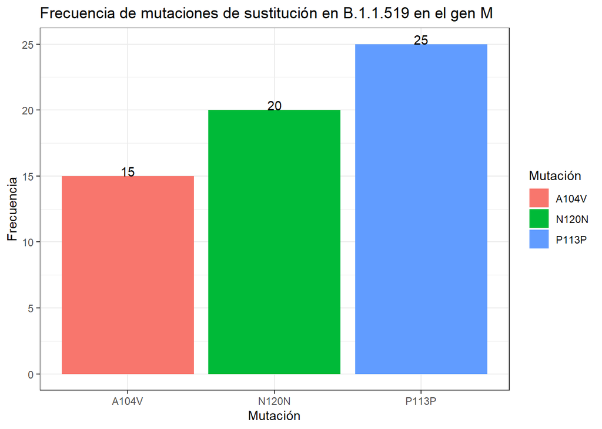

```r
grafica_M
```

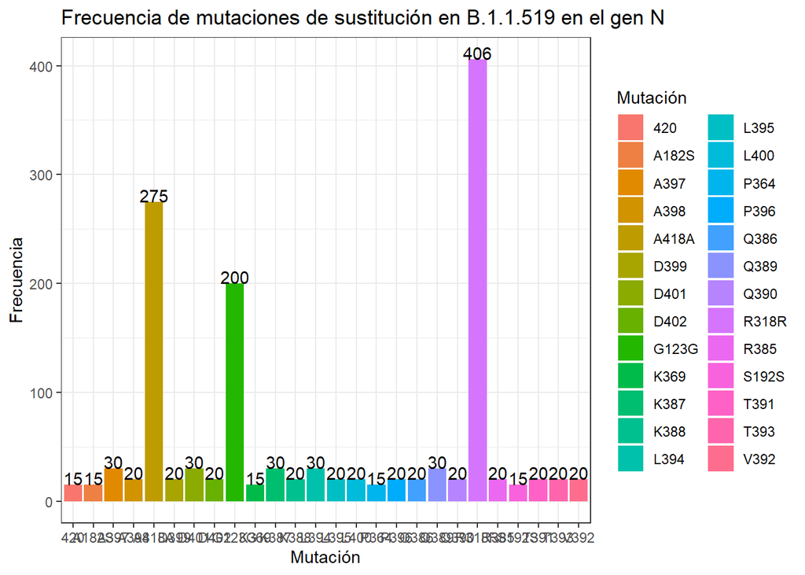

```r
grafica_N
```

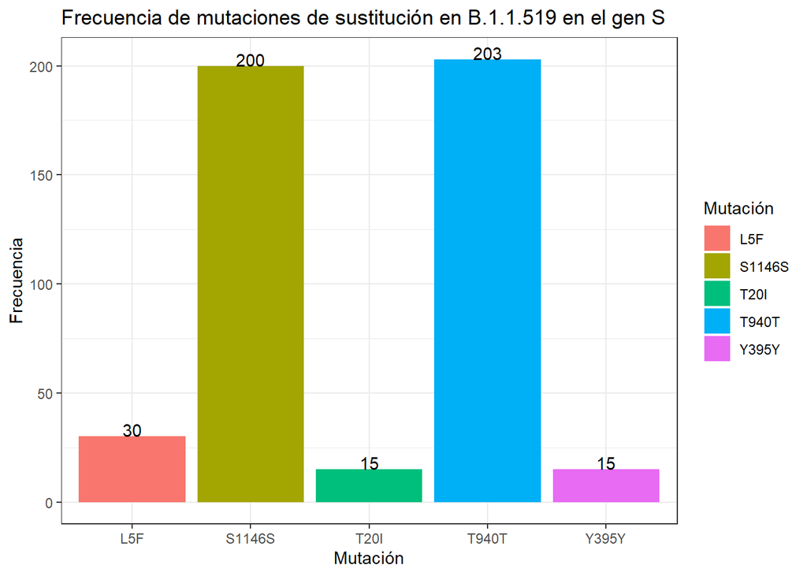

```r
grafica_S
```